# Poisson Regression

BMLR Chapter 4

Author

Affiliation

Ann Cannon

Cornell College  
STA 363 Fall 2026 Block 1

## Setup

```r
library(tidyverse)
library(tidymodels)
library(GGally)
library(knitr)
library(patchwork)
library(viridis)
library(ggfortify)
library(gridExtra)
```

## Learning goals (1/2)

- Describe properties of the Poisson random variable
- Write the Poisson regression model
- Describe how the Poisson regression differs from least-squares regression
- Interpret the coefficients for the Poisson regression model
- Compare two Poisson regression models
- Define and calculate residuals for the Poisson regression model
- Use Goodness-of-fit to assess model fit

## Learning goals (2/2)

- Identify overdispersion
- Apply modeling approaches to deal with overdispersion
- Explore properties of negative binomial versus Poisson response
- Fit and interpret models with offset to adjust for differences in sampling effort
- Fit and interpret Zero-inflated Poisson models
- Write likelihood for Poisson and Zero-inflated Poisson model
- Summarize GLMs for independent observations

## Scenarios to use Poisson regression

- Does the number of employers conducting on-campus interviews during a year differ for public and private colleges?
- Does the daily number of asthma-related visits to an Emergency Room differ depending on air pollution indices?
- Does the number of paint defects per square foot of wall differ based on the years of experience of the painter?

. . .

Each response variable is a count per unit of time or space.

## Poisson distribution

Let $Y$ be the number of events in a given unit of time or space. Then $Y$ can be modeled using a *Poisson distribution*

. . .

$$P(Y=y) = \frac{e^{-\lambda}\lambda^y}{y!} \hspace{10mm} y=0,1,2,\ldots, \infty$$

## Poisson Features

- $E(Y) = \mu = Var(Y) = \sigma^2 = \lambda$
- The distribution is typically skewed right, particularly if $\lambda$ is small
- The distribution becomes more symmetric as $\lambda$ increases
  - If $\lambda$ is sufficiently large, it can be approximated using a normal distribution ([Click here](https://online.stat.psu.edu/stat414/Lesson28#normal-approximation-to-poisson) for an example.)

## Poisson Graphs

**Graphs**

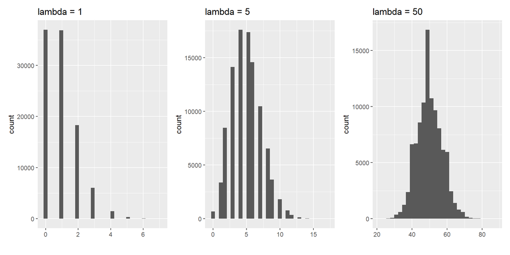

**Table**

|  | Mean | Variance |
| --- | --- | --- |
| lambda = 1 | 0.99351 | 0.9902178 |
| lambda = 5 | 4.99367 | 4.9865798 |
| lambda = 50 | 49.99288 | 49.8962683 |

## Example

The annual number of earthquakes registering at least 2.5 on the Richter Scale and having an epicenter within 40 miles of downtown Memphis follows a Poisson distribution with mean 6.5. **What is the probability there will be at 3 or fewer such earthquakes next year?**

. . .

$$P(Y \leq 3) = P(Y = 0) + P(Y = 1) + P(Y = 2) + P(Y = 3)$$

. . .

$$= \frac{e^{-6.5}6.5^0}{0!} + \frac{e^{-6.5}6.5^1}{1!} + \frac{e^{-6.5}6.5^2}{2!} + \frac{e^{-6.5}6.5^3}{3!}$$

. . .

$$= 0.112$$

. . .

```r
ppois(3, 6.5)
```

```
[1] 0.1118496
```

Example adapted from [Introduction to Probability Theory Example 28-2](https://online.stat.psu.edu/stat414/lesson/28/28.2)

# Poisson regression

## Poisson regression

**The data: Household size in the Philippines**

The data fHH1.csv come from the 2015 Family Income and Expenditure Survey conducted by the Philippine Statistics Authority.

**Goal**: Understand the association between household size and various characteristics of the household

**Response**:

- `total`: Number of people in the household other than the head

**Predictors**:

- `location`: Where the house is located
- `age`: Age of the head of household
- `roof`: Type of roof on the residence (proxy for wealth)

**Other variables**:

- `numLT5`: Number in the household under 5 years old

## The data

```r
hh_data <- read_csv("data/fHH1.csv")
hh_data |> slice(1:5) |> kable()
```

| location | age | total | numLT5 | roof |
| --- | --- | --- | --- | --- |
| CentralLuzon | 65 | 0 | 0 | Predominantly Strong Material |
| MetroManila | 75 | 3 | 0 | Predominantly Strong Material |
| DavaoRegion | 54 | 4 | 0 | Predominantly Strong Material |
| Visayas | 49 | 3 | 0 | Predominantly Strong Material |
| MetroManila | 74 | 3 | 0 | Predominantly Strong Material |

## Response variable

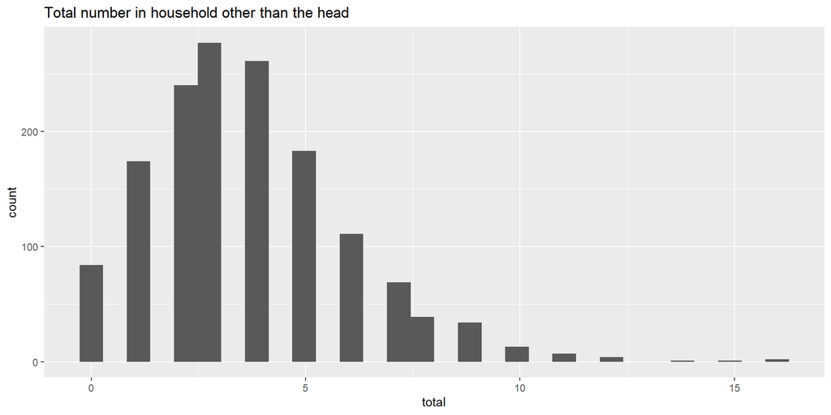

| mean | var |
| --- | --- |
| 3.685 | 5.534 |

## Use GLM to find a model for $\lambda$?

The goal is to model $\lambda$, the expected number of people in the household (other than the head), as a function of the predictors (covariates)

**Questions**

1. Can the distribution of the response variable be written in a one-parameter exponential family form? $f(y;\lambda)=e^{[a(y)b(\lambda)+c(\lambda)+d(y)]}$
2. Does the support depend on the parameter $(\lambda)$?
- If the answer to 1 is yes and the answer to 2 is no, then we can use the canonical link and try modeling $b(\lambda)= \beta_0 + \beta_1 x_1 + \beta_2 x_2 + ...$

**Answers**

1. $P(Y=y)=\frac{e^{-\lambda}\lambda^y}{y!}=e^{-\lambda}e^{ylog\lambda}e^{-\log(y!)}=e^{y\log\lambda-\lambda-\log(y!)}$ which is in the one-parameter exponential family form.
2. The support of the probabilty function is $y=0,1,2,...$ which does not depend on $\lambda$.
- This suggests that the model should be in the form $\log(\lambda)=\beta_0 + \beta_1 x_1 + \beta_2 x_2 + ...$

## Poisson regression model

If $Y_i \sim Poisson$ with $\lambda = \lambda_i$ for the given values $x_{i1}, \ldots, x_{ip}$, then

$$\log(\lambda_i) = \beta_0 + \beta_1 x_{i1} + \beta_2 x_{i2} + \dots + \beta_p x_{ip}$$

- Each observation can have a different value of $\lambda$ based on its value of the predictors $x_1, \ldots, x_p$
- $\lambda$ determines the mean and variance, so we don’t need to estimate a separate error term

## Poisson vs. multiple linear regression

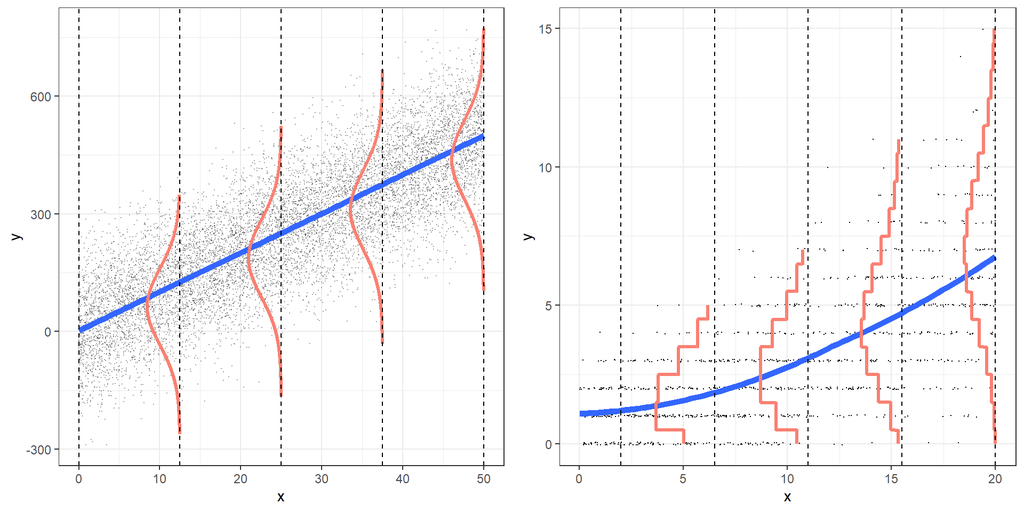

Regression models: Linear regression (left) and Poisson regression (right).

From [BMLR Figure 4.1](https://bookdown.org/roback/bookdown-BeyondMLR/ch-poissonreg.html#a-graphical-look-at-poisson-regression)

## Assumptions for Poisson regression

**Poisson response**: The response variable is a count per unit of time or space, described by a Poisson distribution, at each level of the predictor(s)

**Independence**: The observations must be independent of one another

**Mean = Variance**: The mean must equal the variance

**Linearity**: The log of the mean rate, $\log(\lambda)$, must be a linear function of the predictor(s)

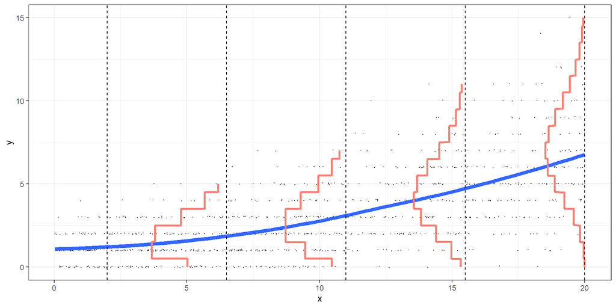

## Model 1: Number in household vs. age

```r
model1 <- glm(total ~ age, data = hh_data, family = poisson)

tidy(model1) |>
  kable(digits = 4)
```

| term | estimate | std.error | statistic | p.value |
| --- | --- | --- | --- | --- |
| (Intercept) | 1.5499 | 0.0503 | 30.8290 | 0 |
| age | -0.0047 | 0.0009 | -5.0258 | 0 |

$$\log(\hat{\lambda}) = 1.5499 - 0.0047 ~ age$$

. . .

Question: The coefficient for `age` is -0.0047. Interpret this coefficient in context.

## Answers

- Each additional year older the head of household is, the estimated average log of the number of people in the household is .0047 lower.
- Each additional year older the head of household is, the estimated average number of people in the household reduces by 0.5%.
- Each additional year older the head of household is, the estimated average number of people in the household changes by a factor of .995.
- For every 10 years older the head of household is, the estimated average number of people in the household reduces by 5%.

## Understanding the interpretation

Let’s derive the change in predicted mean when we go from $x$ to $x+1$

(see boardwork)

## Is the coefficient of `age` statistically significant?

| term | estimate | std.error | statistic | p.value | conf.low | conf.high |
| --- | --- | --- | --- | --- | --- | --- |
| (Intercept) | 1.5499 | 0.0503 | 30.8290 | 0 | 1.4512 | 1.6482 |
| age | -0.0047 | 0.0009 | -5.0258 | 0 | -0.0065 | -0.0029 |

$$H_0: \beta_1 = 0 \hspace{2mm} \text{ vs. } \hspace{2mm} H_a: \beta_1 \neq 0$$

. . .

**Test statistic**

$$Z = \frac{\hat{\beta}_1 - 0}{SE(\hat{\beta}_1)} = \frac{-0.0047 - 0}{0.0009} = -5.026 \text{ (using exact values)}$$

. . .

**P-value**

$$P(|Z| > |-5.026|) = 5.01 \times 10^{-7} \approx 0$$

## What are plausible values for the coefficient of `age`?

| term | estimate | std.error | statistic | p.value | conf.low | conf.high |
| --- | --- | --- | --- | --- | --- | --- |
| (Intercept) | 1.5499 | 0.0503 | 30.8290 | 0 | 1.4512 | 1.6482 |
| age | -0.0047 | 0.0009 | -5.0258 | 0 | -0.0065 | -0.0029 |

**95% confidence interval for the coefficient of `age`**

$$\hat{\beta}_1 \pm Z^{*}\times SE(\hat{\beta}_1)$$
$$-0.0047 \pm 1.96 \times 0.0009 = \mathbf{(-.0065, -0.0029)}$$

. . .

Question: Interpret the interval in terms of the change in mean household size.

## **Which can help determine if Model 1 is a good fit?**

**Plots**

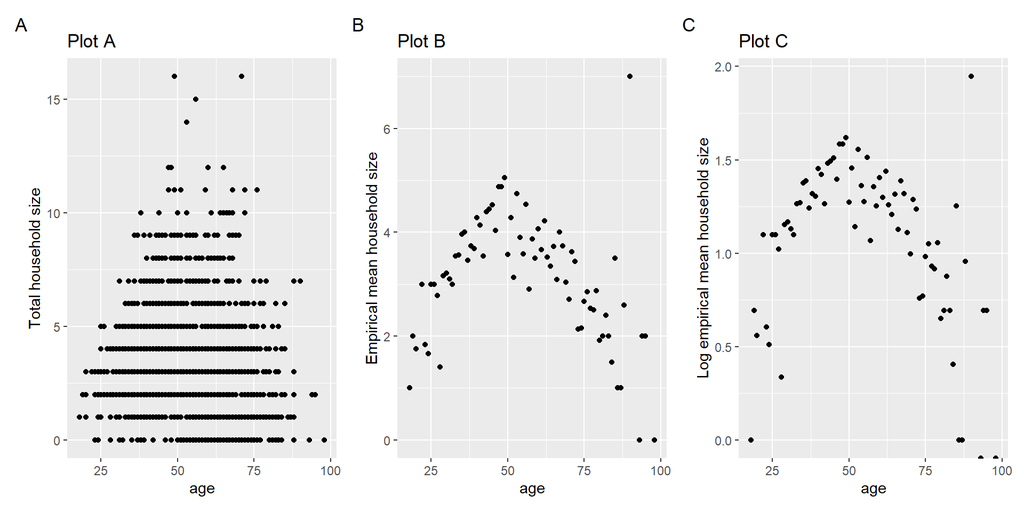

**Code**

```r
p1 <- ggplot(data = hh_data, aes(x = age, y = total)) +
  geom_point() +
  labs(y = "Total household size",
       title = "Plot A")

p2 <- hh_data |>
  group_by(age) |>
  summarise(mean = mean(total)) |>
  ggplot(aes(x = age, y = mean))+
  geom_point() +
  labs(y = "Empirical mean household size",
       title = "Plot B")

p3 <- hh_data |>
  group_by(age) |>
  summarise(log_mean = log(mean(total))) |>
  ggplot(aes(x = age, y = log_mean)) +
  geom_point() +
  labs(y = "Log empirical mean household size",
       title = "Plot C")

p1 + p2 + p3 + plot_annotation(tag_levels = 'A')
```

## Model 2: Add a quadratic effect for `age`

```r
hh_data <- hh_data |>
  mutate(age2 = age*age)

model2 <- glm(total ~ age + age2, data = hh_data, family = poisson)
tidy(model2, conf.int = T) |>
  kable(digits = 4)
```

| term | estimate | std.error | statistic | p.value | conf.low | conf.high |
| --- | --- | --- | --- | --- | --- | --- |
| (Intercept) | -0.3325 | 0.1788 | -1.8594 | 0.063 | -0.6863 | 0.0148 |
| age | 0.0709 | 0.0069 | 10.2877 | 0.000 | 0.0575 | 0.0845 |
| age2 | -0.0007 | 0.0001 | -11.0578 | 0.000 | -0.0008 | -0.0006 |

## Model 2: Add a quadratic effect for `age`

| term | estimate | std.error | statistic | p.value | conf.low | conf.high |
| --- | --- | --- | --- | --- | --- | --- |
| (Intercept) | -0.3325 | 0.1788 | -1.8594 | 0.063 | -0.6863 | 0.0148 |
| age | 0.0709 | 0.0069 | 10.2877 | 0.000 | 0.0575 | 0.0845 |
| age2 | -0.0007 | 0.0001 | -11.0578 | 0.000 | -0.0008 | -0.0006 |

We can determine whether to keep $age^2$ in the model in two ways:

1️⃣ Use the p-value (or confidence interval) for the coefficient (since we are adding a single term to the model)

2️⃣ Conduct a drop-in-deviance test

## Drop-in-Deviance Test

As with logistic regression, we can use a **drop-in-deviance test** to compare two models. To conduct the test

1️⃣ Compute the deviance for each model

2️⃣ Calculate the drop in deviance

$$\text{drop-in-deviance = Deviance(reduced model) - Deviance(larger model)}$$

. . .

3️⃣ Given the reduced model is the true model $(H_0 \text{ true})$, then
$$\text{drop-in-deviance} \sim \chi_d^2$$

where $d$ is the difference in degrees of freedom between the two models (i.e., the difference in number of terms)

## Drop-in-deviance - Model1 and Model2

```r
anova(model1, model2, test = "Chisq") |>
  kable(digits = 3)
```

| Resid. Df | Resid. Dev | Df | Deviance | Pr(>Chi) |
| --- | --- | --- | --- | --- |
| 1498 | 2337.089 | NA | NA | NA |
| 1497 | 2200.944 | 1 | 136.145 | 0 |

. . .

Questions:

- Write the null and alternative hypotheses.
- What does the value 2337.089 tell you?
- What does the value 1 tell you?
- What is your conclusion?

## Add `location` to the model?

Suppose we want to add `location` to the model, so we compare the following models:

**Model A**: $\lambda_i = \beta_0 + \beta_1 ~ age_i + \beta_2 ~ age_i^2$

**Model B**: $\lambda_i = \beta_0 + \beta_1 ~ age_i + \beta_2 ~ age_i^2 + \beta_3 ~ Loc1_i + \beta_4 ~ Loc2_i + \beta_5 ~ Loc3_i + \beta_6 ~ Loc4_i$

## Question

Which of the following are reliable ways to determine if `location` should be added to the model?

- Drop-in-deviance test
- Use the p-value for each coefficient
- Likelihood ratio test
- Nested F Test
- BIC

## Add `location` to the model?

```r
model3 <- glm(total ~ age + age2 + location, data = hh_data, family = poisson)
```

. . .

Use a **drop-in-deviance** test to determine if Model 2 or Model 3 (with location) is a better fit for the data.

. . .

```r
anova(model2, model3, test = "Chisq") |>
  kable(digits = 3)
```

| Resid. Df | Resid. Dev | Df | Deviance | Pr(>Chi) |
| --- | --- | --- | --- | --- |
| 1497 | 2200.944 | NA | NA | NA |
| 1493 | 2187.800 | 4 | 13.144 | 0.011 |

The p-value is small (0.01 < 0.05), so we conclude that Model 3 is a better fit for the data.

## Model 3

| term | estimate | std.error | statistic | p.value | conf.low | conf.high |
| --- | --- | --- | --- | --- | --- | --- |
| (Intercept) | -0.3843 | 0.1821 | -2.1107 | 0.0348 | -0.7444 | -0.0306 |
| age | 0.0704 | 0.0069 | 10.1900 | 0.0000 | 0.0569 | 0.0840 |
| age2 | -0.0007 | 0.0001 | -10.9437 | 0.0000 | -0.0008 | -0.0006 |
| locationDavaoRegion | -0.0194 | 0.0538 | -0.3605 | 0.7185 | -0.1250 | 0.0859 |
| locationIlocosRegion | 0.0610 | 0.0527 | 1.1580 | 0.2468 | -0.0423 | 0.1641 |
| locationMetroManila | 0.0545 | 0.0472 | 1.1542 | 0.2484 | -0.0378 | 0.1473 |
| locationVisayas | 0.1121 | 0.0417 | 2.6853 | 0.0072 | 0.0308 | 0.1945 |

. . .

**Does this model sufficiently explain the variability in the mean household size?**

# Goodness-of-fit

## Pearson residuals

We can calculate two types of residuals for Poisson regression: Pearson residuals and deviance residuals

. . .

$$\text{Pearson residual}_i = \frac{\text{observed} - \text{predicted}}{\text{std. error}} = \frac{y_i - \hat{\lambda}_i}{\sqrt{\hat{\lambda}_i}}$$

. . .

- Similar interpretation as standardized residuals from linear regression
- Expect most to fall between -2 and 2
- Used to calculate overdispersion parameter

## Deviance residuals

The **deviance residuals** indicate how much the observed data deviates from the fitted model

$$\text{deviance residual}_i = \text{sign}(y_i - \hat{\lambda}_i)\sqrt{2\Bigg[y_i\log\bigg(\frac{y_i}{\hat{\lambda}_i}\bigg) - (y_i - \hat{\lambda}_i)\Bigg]}$$

where

$$\text{sign}(y_i - \hat{\lambda}_i) = \begin{cases}
1 & \text{ if }(y_i - \hat{\lambda}_i) > 0 \\
-1 & \text{ if }(y_i - \hat{\lambda}_i) < 0 \\
0 & \text{ if }(y_i - \hat{\lambda}_i) = 0
\end{cases}$$

. . .

$$\text{residual deviance} = \sum{\left(\text{deviance residual}\right)_i^2}$$

## Model 3: Residual plots

```r
model3_aug_pearson <- augment(model3, type.residuals = "pearson")
model3_aug_deviance <- augment(model3, type.residuals = "deviance")
```

**Plots**

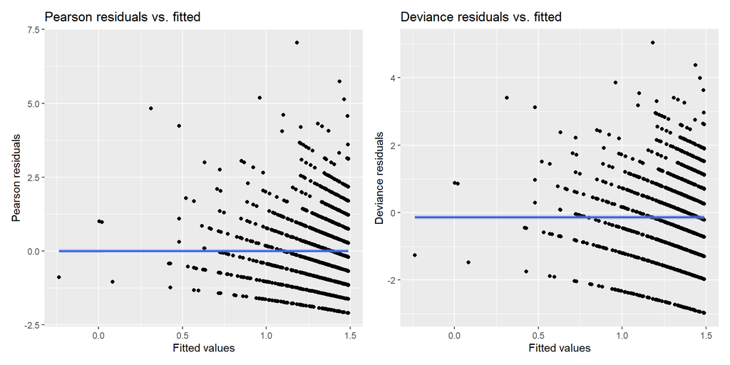

**Code**

```r
p1 <- ggplot(data = model3_aug_pearson, aes(x = .fitted, y = .resid)) +
  geom_point()  +
  geom_smooth() +
  labs(x = "Fitted values",
       y = "Pearson residuals",
       title = "Pearson residuals vs. fitted")

p2 <-  ggplot(data = model3_aug_deviance, aes(x = .fitted, y = .resid)) +
  geom_point()  +
  geom_smooth() +
  labs(x = "Fitted values",
       y = "Deviance residuals",
       title = "Deviance residuals vs. fitted")

p1 + p2
```

## Goodness-of-fit

- **Goal**: Use the (residual) deviance to assess how much the predicted values differ from the observed values. Recall $(\text{deviance}) = \sum_{i=1}^{n}(\text{deviance residual})_i^2$
- If the model sufficiently fits the data, then

. . .

$$\text{deviance} \sim \chi^2_{df}$$

where $df$ is the model’s residual degrees of freedom

. . .

- **Question**: What is the probability of observing a deviance larger than the one we’ve observed, given this model sufficiently fits the data?

. . .

$$P(\chi^2_{df} > \text{ deviance})$$

## Model 3: Goodness-of-fit calculations

```r
model3$deviance
```

```
[1] 2187.8
```

```r
model3$df.residual
```

```
[1] 1493
```

```r
pchisq(model3$deviance, model3$df.residual, lower.tail = FALSE)
```

```
[1] 3.153732e-29
```

The probability of observing a deviance greater than 2187.8 is $\approx 0$, so there is significant evidence of **lack-of-fit**.

## Lack-of-fit

There are a few potential reasons for lack-of-fit:

- Missing important interactions or higher-order terms
- Missing important variables (perhaps this means a more comprehensive data set is required)
- There could be extreme observations causing the deviance to be larger than expected (assess based on the residual plots)
- There could be a problem with the Poisson model
  - May need more flexibility in the model to handle **overdispersion**

## Overdispersion

**Overdispersion**: There is more variability in the response than what is implied by the Poisson model

**Tables**

**Overall**

| mean | var |
| --- | --- |
| 3.685 | 5.534 |

**by Location**

| location | mean | var |
| --- | --- | --- |
| CentralLuzon | 3.402 | 4.152 |
| DavaoRegion | 3.390 | 4.723 |
| IlocosRegion | 3.586 | 5.402 |
| MetroManila | 3.707 | 4.863 |
| Visayas | 3.902 | 6.602 |

**Code**

```r
hh_data |>
  summarise(mean = mean(total), var = var(total)) |>
  kable(digits = 3)
```

```r
hh_data |>
  group_by(location) |>
  summarise(mean = mean(total), var = var(total)) |>
  kable(digits = 3)
```

## Why overdispersion matters

If there is overdispersion, then there is more variation in the response than what’s implied by a Poisson model. This means

❌ The standard errors of the model coefficients are artificially small

❌ The p-values are artificially small

❌ This could lead to models that are more complex than what is needed

. . .

We can take overdispersion into account by

- inflating standard errors by multiplying them by a dispersion factor
- using a negative-binomial regression model

# Quasi-poission

## Dispersion parameter

The **dispersion parameter** is represented by $\phi$

- If there is no overdispersion $\hat{\phi} = 1$
- If there is overdispersion $\hat{\phi} > 1$

## Accounting for dispersion in the model

We inflate the standard errors of the coefficient by multiplying the variance by $\hat{\phi}$

. . .

$$SE_{Q}(\hat{\beta}) = \sqrt{\hat{\phi}} * SE(\hat{\beta})$$
- “Q” stands for **quasi-Poisson**, since this is an ad-hoc solution - The process for model building and model comparison is called **quasilikelihood** (similar to likelihood without exact underlying distributions)

## Model 3: Quasi-Poisson model

```r
model3_q <- glm(total ~ age + age2 + location, data = hh_data,
                family = quasipoisson) #<<
```

| term | estimate | std.error | statistic | p.value | conf.low | conf.high |
| --- | --- | --- | --- | --- | --- | --- |
| (Intercept) | -0.3843 | 0.2166 | -1.7744 | 0.0762 | -0.8134 | 0.0358 |
| age | 0.0704 | 0.0082 | 8.5665 | 0.0000 | 0.0544 | 0.0866 |
| age2 | -0.0007 | 0.0001 | -9.2000 | 0.0000 | -0.0009 | -0.0006 |
| locationDavaoRegion | -0.0194 | 0.0640 | -0.3030 | 0.7619 | -0.1451 | 0.1058 |
| locationIlocosRegion | 0.0610 | 0.0626 | 0.9735 | 0.3304 | -0.0620 | 0.1837 |
| locationMetroManila | 0.0545 | 0.0561 | 0.9703 | 0.3320 | -0.0552 | 0.1649 |
| locationVisayas | 0.1121 | 0.0497 | 2.2574 | 0.0241 | 0.0156 | 0.2103 |

## Poisson vs. Q-Poisson

**Poisson**

| term | estimate | std.error |
| --- | --- | --- |
| (Intercept) | -0.3843 | 0.1821 |
| age | 0.0704 | 0.0069 |
| age2 | -0.0007 | 0.0001 |
| locationDavaoRegion | -0.0194 | 0.0538 |
| locationIlocosRegion | 0.0610 | 0.0527 |
| locationMetroManila | 0.0545 | 0.0472 |
| locationVisayas | 0.1121 | 0.0417 |

**Quasi-Poisson**

| estimate | std.error |
| --- | --- |
| -0.3843 | 0.2166 |
| 0.0704 | 0.0082 |
| -0.0007 | 0.0001 |
| -0.0194 | 0.0640 |
| 0.0610 | 0.0626 |
| 0.0545 | 0.0561 |
| 0.1121 | 0.0497 |

## Q-Poisson: Inference for coefficients

| term | estimate | std.error |
| --- | --- | --- |
| (Intercept) | -0.3843 | 0.2166 |
| age | 0.0704 | 0.0082 |
| age2 | -0.0007 | 0.0001 |
| locationDavaoRegion | -0.0194 | 0.0640 |
| locationIlocosRegion | 0.0610 | 0.0626 |
| locationMetroManila | 0.0545 | 0.0561 |
| locationVisayas | 0.1121 | 0.0497 |

**Test statistic**
$$t = \frac{\hat{\beta} - 0}{SE_{Q}(\hat{\beta})} \sim t_{n-p}$$

# Negative binomial regression model

## Negative binomial regression model

Another approach to handle overdispersion is to use a **negative binomial regression model**

- This has more flexibility than the quasi-Poisson model, because there is a new parameter in addition to $\lambda$

. . .

Let $Y$ be a **negative binomial random variable**, $Y\sim NegBinom(r, p)$, then

$$P(Y = y_i) = {y_i + r - 1 \choose r - 1}(1-p)^{y_i}p^r \hspace{5mm} y_i = 0, 1, 2, \ldots, \infty$$

## Negative binomial regression model

- **Main idea**: Generate a $\lambda$ for each observation (household) and generate a count using the Poisson random variable with parameter $\lambda$
  - Makes the counts more dispersed than with a single parameter
- Think of it as a Poisson model such that $\lambda$ is also random

. . .

$\begin{aligned} &\text{If }Y|\lambda \sim Poisson(\lambda)\\ &\text{ and } \lambda \sim Gamma\bigg(r, \frac{1-p}{p}\bigg)\\ &\text{ then } Y \sim NegBinom(r, p)\end{aligned}$

## Negative binomial regression in R

```r
library(MASS)
model3_nb <- glm.nb(total ~ age + age2 + location, data = hh_data)
tidy(model3_nb) |>
  kable(digits = 4)
```

| term | estimate | std.error | statistic | p.value |
| --- | --- | --- | --- | --- |
| (Intercept) | -0.3753 | 0.2076 | -1.8081 | 0.0706 |
| age | 0.0699 | 0.0079 | 8.8981 | 0.0000 |
| age2 | -0.0007 | 0.0001 | -9.5756 | 0.0000 |
| locationDavaoRegion | -0.0219 | 0.0625 | -0.3501 | 0.7262 |
| locationIlocosRegion | 0.0577 | 0.0615 | 0.9391 | 0.3477 |
| locationMetroManila | 0.0562 | 0.0551 | 1.0213 | 0.3071 |
| locationVisayas | 0.1104 | 0.0487 | 2.2654 | 0.0235 |

## Compare all three models

[output not shown]

# Offsets

## Data: Airbnbs in NYC

The data set NYCairbnb-sample.csv contains information about a random sample of 1000 Airbnbs in New York City. It is a subset of the data on 40628 Airbnbs scraped by Awad et al. (2017).

**Variables**

- `number_of_reviews`: Number of reviews for the unit on Airbnb (proxy for number of rentals)
- `price`: price per night in US dollars
- `room_type`: Entire home/apartment, private room, or shared room
- `days`: Number of days the unit has been listed (date when info scraped - date when unit first listed on Airbnb)

Data set pulled from BMLR Section 4.11.3.

## Data: Airbnbs in NYC

```r
airbnb <- read_csv("data/NYCairbnb-sample.csv") |>
  dplyr::select(id, number_of_reviews, days, room_type, price)
```

| id | number_of_reviews | days | room_type | price |
| --- | --- | --- | --- | --- |
| 15756544 | 16 | 1144 | Private room | 120 |
| 14218251 | 15 | 471 | Private room | 89 |
| 21644 | 0 | 2600 | Private room | 89 |
| 13667835 | 1 | 283 | Entire home/apt | 150 |
| 265912 | 0 | 1970 | Entire home/apt | 89 |

**Goal**: Use the price and room type of Airbnbs to describe variation in the number of reviews (a proxy for number of rentals).

## EDA

**Plot**

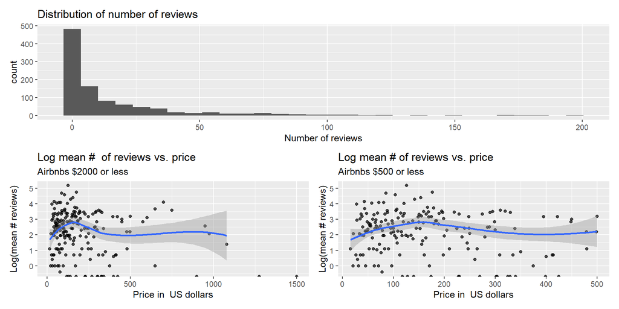

**Code**

```r
p1 <- ggplot(data = airbnb, aes(x = number_of_reviews)) +
  geom_histogram() +
   labs(x = "Number of reviews",
    title = "Distribution of number of reviews")

p2 <- airbnb |>
  filter(price <= 2000) |>
  group_by(price) |>
  summarise(log_mean = log(mean(number_of_reviews))) |>
  ggplot(aes(x = price, y = log_mean)) +
  geom_point(alpha= 0.7) +
  geom_smooth() +
  labs(x = "Price in  US dollars",
    y = "Log(mean # reviews)",
    title = "Log mean #  of reviews vs. price",
    subtitle = "Airbnbs $2000 or less")

p3 <- airbnb |>
  filter(price <= 500) |>
  group_by(price) |>
  summarise(log_mean = log(mean(number_of_reviews))) |>
  ggplot(aes(x = price, y = log_mean)) +
  geom_point(alpha= 0.7) +
  geom_smooth() +
  labs(x = "Price in  US dollars",
    y = "Log(mean # reviews)",
    title = "Log mean # of reviews vs. price",
    subtitle = "Airbnbs $500 or less")

p1  / (p2 + p3)
```

## EDA

**Overall**

| mean | var |
| --- | --- |
| 15.916 | 765.969 |

**by Room type**

| room_type | mean | var |
| --- | --- | --- |
| Entire home/apt | 16.283 | 760.348 |
| Private room | 15.608 | 786.399 |
| Shared room | 15.028 | 605.971 |

## Considerations for modeling

We would like to fit the Poisson regression model

$$\log(\lambda) = \beta_0 + \beta_1 ~ price + \beta_2 ~ room\_type1 + \beta_3 ~ room\_type2$$

. . .

Question: - Based on the EDA, what are some potential issues we may want to address in the model building?

- Suppose any model fit issues are addressed. What are some potential limitations to the conclusions and interpretations from the model?

## Offset

- Sometimes counts are not directly comparable because the observations differ based on some characteristic directly related to the counts, i.e. the *sampling effort*.
- An **offset** can be used to adjust for differences in sampling effort.

. . .

- Let $x_{offset}$ be the variable that accounts for differences in sampling effort, then $\log(x_{offset})$ will be added to the model.

. . .

$\log(\lambda_i) = \beta_0 + \beta_1 ~ x_{i1} + \beta_2 ~ x_{i2} + ... + \beta_p ~ x_{ip} + \log(x_{offset_i})$

- The offset is a term in the model with coefficient always equal to 1.

## Adding an offset to the Airbnb model

We will add the offset $\log(days)$ to the model. This accounts for the fact that we would expect Airbnbs that have been listed longer to have more reviews.

$$\log(\lambda_i) = \beta_0 + \beta_1 ~ price_i + \beta_2 ~ room\_type1_i + \beta_3 ~ room\_type2_i + \log(days_i)$$

**Note:** The response variable for the model is still $\log(\lambda_i)$, the log mean number of reviews

## Detail on the offset

We want to adjust for the number of days, so we are interested in $\frac{reviews}{days}$.

. . .

Given $\lambda$ is the mean number of reviews

$$\log\Big(\frac{\lambda}{days}\Big) = \beta_0 + \beta_1 ~ price + \beta_2 ~ room\_type1 + \beta_3 ~ room\_type2$$

. . .

$$\Rightarrow \log({\lambda}) - \log(days) = \beta_0 + \beta_1 ~ price + \beta_2 ~ room\_type1 + \beta_3 ~ room\_type2$$

. . .

$$\Rightarrow \log({\lambda}) = \beta_0 + \beta_1 ~ price + \beta_2 ~ room\_type1 + \beta_3 ~ room\_type2 + \log(days)$$

## Airbnb model in R

```r
airbnb_model <- glm(number_of_reviews ~ price + room_type,
                    data = airbnb, family = poisson,
                    offset = log(days)) #<<
```

| term | estimate | std.error | statistic | p.value |
| --- | --- | --- | --- | --- |
| (Intercept) | -4.1351 | 0.0170 | -243.1397 | 0 |
| price | -0.0005 | 0.0001 | -7.0952 | 0 |
| room_typePrivate room | -0.0994 | 0.0174 | -5.6986 | 0 |
| room_typeShared room | 0.2436 | 0.0452 | 5.3841 | 0 |

. . .

The coefficient for $\log(days)$ is fixed at 1, so it is not in the model output.

## Interpretations

| term | estimate | std.error | statistic | p.value |
| --- | --- | --- | --- | --- |
| (Intercept) | -4.1351 | 0.0170 | -243.1397 | 0 |
| price | -0.0005 | 0.0001 | -7.0952 | 0 |
| room_typePrivate room | -0.0994 | 0.0174 | -5.6986 | 0 |
| room_typeShared room | 0.2436 | 0.0452 | 5.3841 | 0 |

Question:

- Interpret the coefficient of `price`.
- Interpret the coefficient of `room_typePrivate room`

## Goodness-of-fit

$$\begin{aligned}&H_0: \text{ The model is a good fit for the data}\\
&H_a: \text{ There is significant lack of fit}\end{aligned}$$

```r
pchisq(airbnb_model$deviance, airbnb_model$df.residual, lower.tail = F)
```

```
[1] 0
```

. . .

There is evidence of significant lack of fit in the model. Therefore, more models would need to be explored that address the issues mentioned earlier.

. . .

*In practice we would assess goodness-of-fit and finalize the model **before** any interpretations and conclusions.*

# Zero-inflated Poisson model

## Data: Weekend drinking

The data `weekend-drinks.csv` contains information from a survey of 77 students in an introductory statistics course on a dry campus.

**Variables**

- `drinks`: Number of drinks they had in the past weekend
- `off_campus`: 1 - lives off campus, 0 otherwise
- `first_year`: 1 - student is a first-year, 0 otherwise
- `sex`: f - student identifies as female, m - student identifies as male

. . .

**Goal**: The goal is explore factors related to drinking behavior on a dry campus.

Case study in BMLR - Section 4.10

## EDA: Response variable

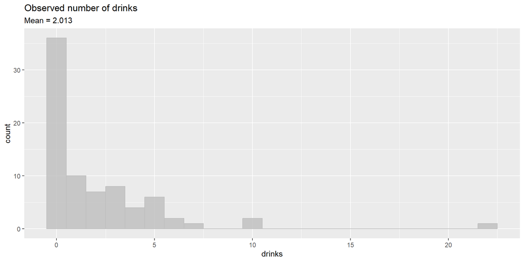

## Observed vs. expected response

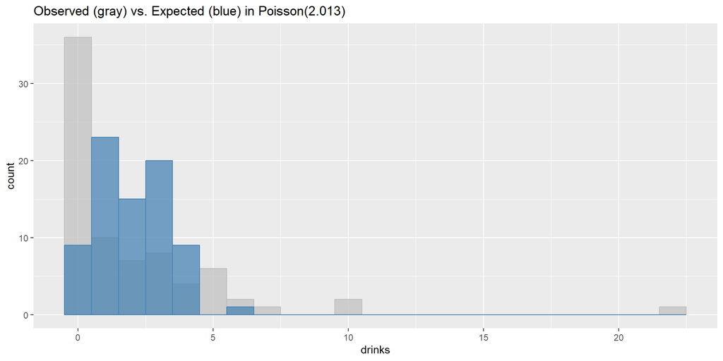

. . .

**What does it mean to be a “zero” in this data?**

## Two types of zeros

There are two types of zeros

- Those who happen to have a zero in the data set (people who drink but happened to not drink last weekend)
- Those who will always report a value of zero (non-drinkers)
  - These are called **true zeros**

. . .

We introduce a new parameter $\alpha$ for the proportion of true zeros, then fit a model that has two components:

. . .

1️⃣ The association between mean number of drinks and various characteristics among those who drink

2️⃣ The estimated proportion of non-drinkers

## Zero-inflated Poisson model

**Zero-inflated Poisson (ZIP)** model has two parts

. . .

1️⃣ Association, among those who drink, between the mean number of drinks and predictors sex and off campus residence

. . .

$$\log(\lambda) = \beta_0 + \beta_1 ~ off\_campus + \beta_2 ~ sex$$
where $\lambda$ is the mean number of drinks among those who drink

. . .

2️⃣ Probability that a student does not drink

$$\text{logit}(\alpha) = \log\Big(\frac{\alpha}{1- \alpha}\Big) = \beta_0 + \beta_1 ~ first\_year$$

where $\alpha$ is the proportion of non-drinkers

. . .

**Note:** The same variables can be used in each component

## Details of the ZIP model

- The ZIP model is a special case of a **latent variable model**
  - A type of **mixture model** where observations for one or more groups occur together but the group membership is unknown
- Zero-inflated models are a common type of mixture model; they apply beyond Poisson regression

## ZIP model in R

Fit ZIP models using the `zeroinfl` function from the **pscl** R package.

```r
library(pscl)

drinks_zip <- zeroinfl(drinks ~ off_campus + sex | first_year,
                data = drinks)
drinks_zip
```

```
Call:
zeroinfl(formula = drinks ~ off_campus + sex | first_year, data = drinks)

Count model coefficients (poisson with log link):
(Intercept)   off_campus         sexm
     0.7543       0.4159       1.0209

Zero-inflation model coefficients (binomial with logit link):
(Intercept)   first_year
    -0.6036       1.1364
```

## Tidy output

Use the `tidy` function from the **poissonreg** package for tidy model output.

```r
library(poissonreg)
```

. . .

**Mean number of drinks among those who drink**

```r
tidy(drinks_zip, type = "count") %>% kable(digits = 3)
```

| term | type | estimate | std.error | statistic | p.value |
| --- | --- | --- | --- | --- | --- |
| (Intercept) | count | 0.754 | 0.144 | 5.238 | 0.000 |
| off_campus | count | 0.416 | 0.206 | 2.021 | 0.043 |
| sexm | count | 1.021 | 0.175 | 5.827 | 0.000 |

## Tidy output

**Proportion of non-drinkers**

```r
tidy(drinks_zip, type = "zero") %>% kable(digits = 3)
```

| term | type | estimate | std.error | statistic | p.value |
| --- | --- | --- | --- | --- | --- |
| (Intercept) | zero | -0.604 | 0.311 | -1.938 | 0.053 |
| first_year | zero | 1.136 | 0.610 | 1.864 | 0.062 |

## Interpreting the model coefficients

| term | type | estimate | std.error | statistic | p.value |
| --- | --- | --- | --- | --- | --- |
| (Intercept) | count | 0.754 | 0.144 | 5.238 | 0.000 |
| off_campus | count | 0.416 | 0.206 | 2.021 | 0.043 |
| sexm | count | 1.021 | 0.175 | 5.827 | 0.000 |

Questions

- Interpret the intercept.
- Interpret the coefficients of `off_campus` and `sexm`.

## Estimated proportion zeros

| term | type | estimate | std.error | statistic | p.value |
| --- | --- | --- | --- | --- | --- |
| (Intercept) | zero | -0.604 | 0.311 | -1.938 | 0.053 |
| first_year | zero | 1.136 | 0.610 | 1.864 | 0.062 |

Questions:

Based on the model…

- What is the probability a first-year student is a non-drinker?
- What is the probability a upperclass student (sophomore, junior, senior) is a non-drinker?

## These are just a few of the many models…

- Use the [Vuong Test](https://bookdown.org/roback/bookdown-BeyondMLR/ch-poissonreg.html#the-vuong-test-optional) to compare the fit of the ZIP model to a regular Poisson model
  - Why can’t we use a drop-in-deviance test?
- We’ve just discussed the ZIP model here, but there are other model applications beyond the standard Poisson regression model (e.g., hurdle models, Zero-inflated Negative Binomial models, etc. )

# Wrap up GLM for independent observations

## Wrap up

- Covered fitting, interpreting, and drawing conclusions from GLMs
  - Looked at Poisson, Negative Binomial, and Logistic (binary, binomial, ordinal) in detail
- Used Pearson and deviance residuals to assess model fit and determine if new variables should be added to the model
- Addressed issues of overdispersion and zero-inflation
- Used the properties of the one-parameter exponential family to identify the best link function for any GLM

. . .

Everything we’ve done thus far as been under the assumption that the observations are *independent*. Looking ahead we will consider models for data with **dependent (correlated) observations**.

## Acknowledgements

These slides are based on content in [BMLR: Chapter 4](https://bookdown.org/roback/bookdown-BeyondMLR/)

Initial versions of the slides are by Dr. Maria Tackett, Duke University